# Medical_Cost_code_01

## Medical Cost analysis

### 0. Introduction

본 분석의 목적은 환자의 특정 특성을 고려하여 특정 시점에 환자에게 발생할 수 있는 의료 비용을 예측할 수 있는 `ML 모델`을 제안하는 것입니다. 이 노트북은 주요 하이퍼 매개변수를 조정하여 `Random Forest` 모델을 사용하는 데만 중점을 둡니다.

데이터는 유명한 데이터 과학자 커뮤니티[Kaggle](https://www.kaggle.com/datasets/mirichoi0218/insurance?datasetId=13720&sortBy=voteCount&searchQuery=random+forest&언어=R)에서 가져왔으며 [Tidymodels](https://www.tidymodels.org/)에서 제공하는 패키지입니다.

#### Columns description

There are 7 columns in the data, which are described below:

- Age : 주요 수혜자의 연령
- Sex: 보험 계약자 성별(여성 또는 남성)
- BMI: 체질량 지수
- Children : 건강보험 적용 자녀 수 / 부양가족 수
- Smoker : 흡연 상태
- Region: 미국 내 수혜자의 거주 지역(북동부, 남동부, 남서부 또는 북서부)
- Charges : 건강보험에서 청구하는 개인의료비

### 1. Exploratory data analysis(EDA)

모든 유형의 모델 설정을 시작하기 전에 데이터를 탐색하여 누락된 값과 같은 불일치가 있는지 확인하고 응답 변수가 다른 모든 변수에 의해 어떻게 영향을 받는지 약간 이해해야 합니다.

#### Dataset overview(데이터 개요)

`skimr` 패키지의 `skim function`을 사용하면 데이터의 모든 변수에 대한 개요를 얻을 수 있습니다.

Data summary

| Name | insurance |
| --- | --- |
| Number of rows | 1338 |
| Number of columns | 7 |
| _______________________ |  |
| Column type frequency: |  |
| factor | 3 |
| numeric | 4 |
| ________________________ |  |
| Group variables | None |

**Variable type: factor**

| skim_variable | n_missing | complete_rate | ordered | n_unique | top_counts |
| --- | --- | --- | --- | --- | --- |
| sex | 0 | 1 | FALSE | 2 | mal: 676, fem: 662 |
| smoker | 0 | 1 | FALSE | 2 | no: 1064, yes: 274 |
| region | 0 | 1 | FALSE | 4 | sou: 364, nor: 325, sou: 325, nor: 324 |

**Variable type: numeric**

| skim_variable | n_missing | complete_rate | mean | sd | p0 | p25 | p50 | p75 | p100 |
| --- | --- | --- | --- | --- | --- | --- | --- | --- | --- |
| age | 0 | 1 | 39.21 | 14.05 | 18.00 | 27.00 | 39.00 | 51.00 | 64.00 |
| bmi | 0 | 1 | 30.66 | 6.10 | 15.96 | 26.30 | 30.40 | 34.69 | 53.13 |
| children | 0 | 1 | 1.09 | 1.21 | 0.00 | 0.00 | 1.00 | 2.00 | 5.00 |
| charges | 0 | 1 | 13270.42 | 12110.01 | 1121.87 | 4740.29 | 9382.03 | 16639.91 | 63770.43 |

따라서 모든 변수에 누락된 값이 없습니다. 평균적으로 모든 피보험자에게는 자녀가 한 명 이상 있고, 자녀가 없는 사람도 많지만 일반적으로 데이터에 등록된 사람들은 비만(bmi >= 30은 [비만]으로 분류됩니다)(https: //www.texasheart.org/heart-health/heart-information-center/topics/calculadora-del-index-de-mass-corporal-bmi/))

#### Distribution of medical charges (진료비 분포)

피보험자가 부담하는 의료비의 경험적(empirical) 분포를 살펴보자.

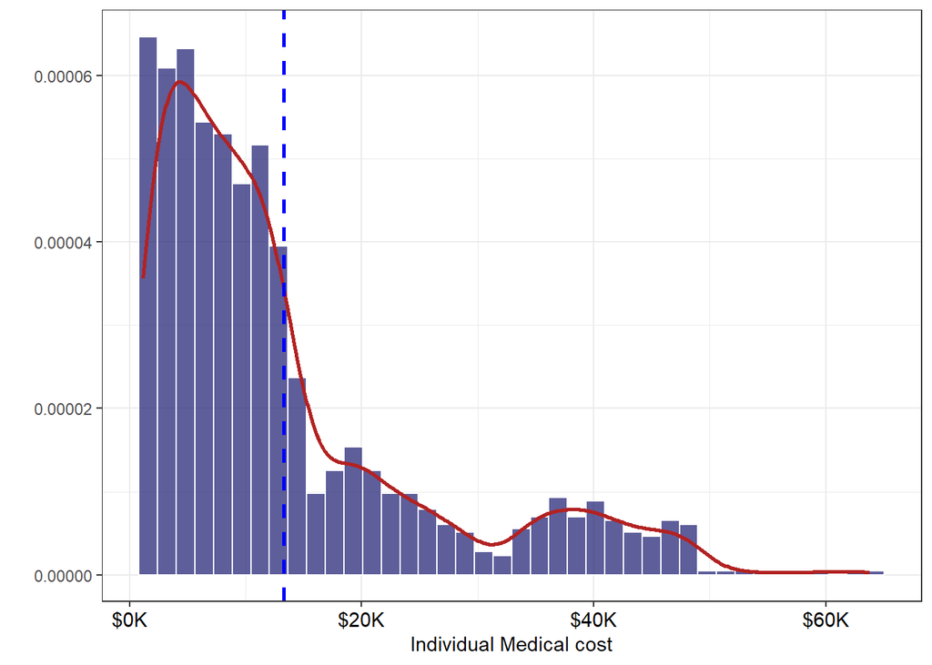

금전적 금액이나 소득을 나타내는 모든 변수는 예상대로 분포가 오른쪽으로 치우쳐 있습니다. 데이터를 정규화하고 분산을 안정화하기 위해 로그 변환을 진행합니다.

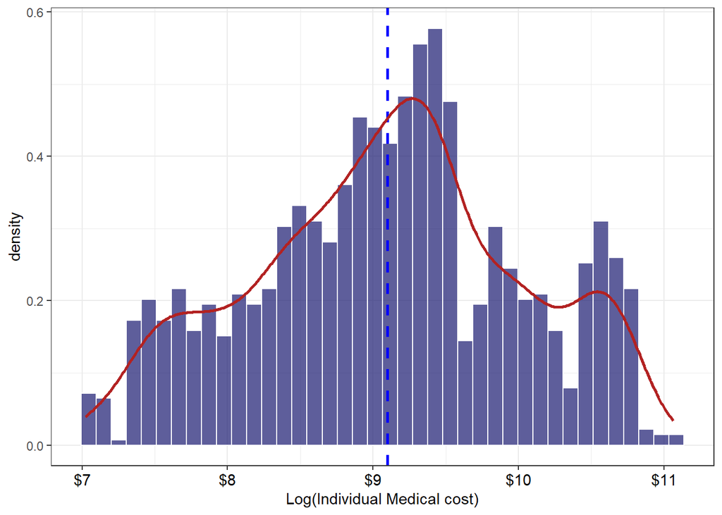

#### Categorical variables(범주형 변수)

다음으로 범주형 변수와 반응 변수 간의 관계를 살펴봅니다. 목표는 모델이 포착할 패턴이 될 중앙값의 변화를 찾는 것입니다.

#### insured(피보험자)의 성별

insured(피보험자) : 보험의 대상이 되는 사람

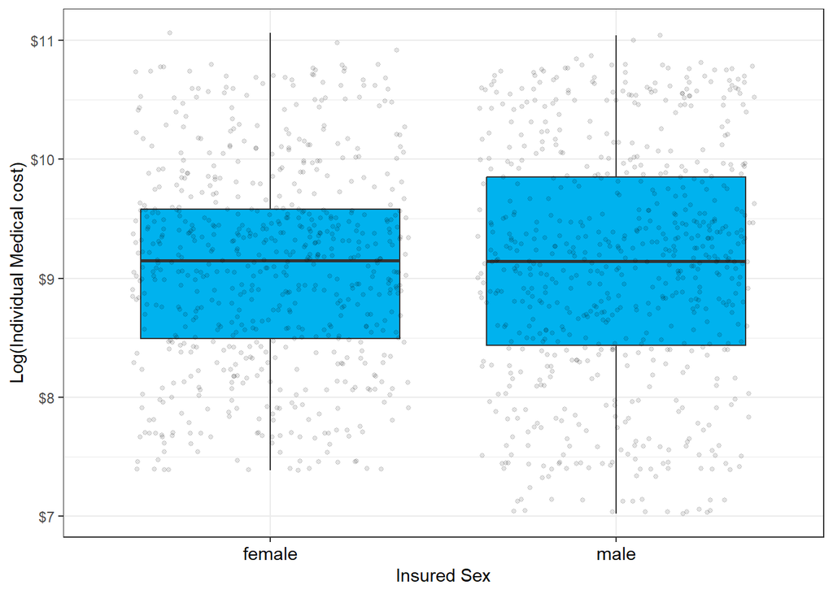

피보험자의 성별에 따른 관련 변화는 관찰되지 않습니다.

#### Active smoking status

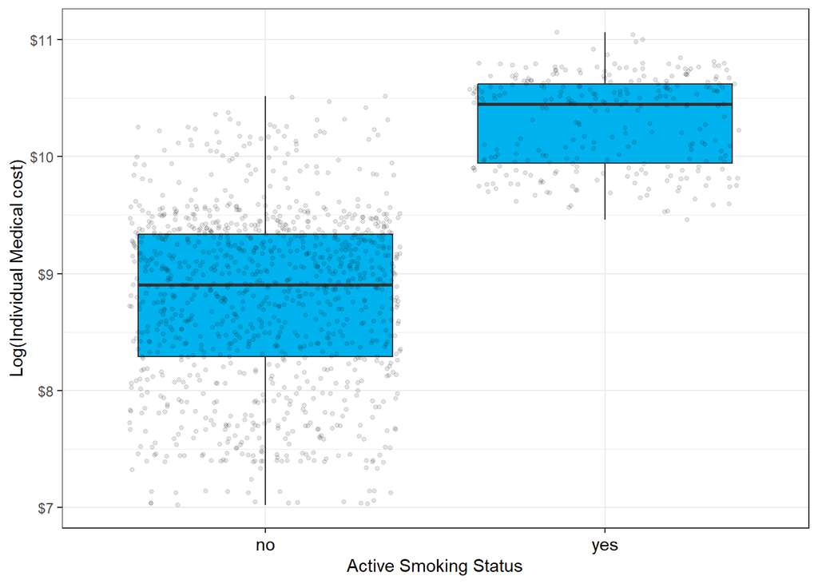

피보험자가 흡연을 하면 의료비가 더 많이 나올 것으로 예상됩니다. 흡연이 건강에 영향을 미치고 신체에도 영향을 미치기 때문에 이 진술은 분명한 것 같습니다.

피보험자의 성별과 현재 흡연자인지 여부 사이에 어떤 관계가 있습니까?

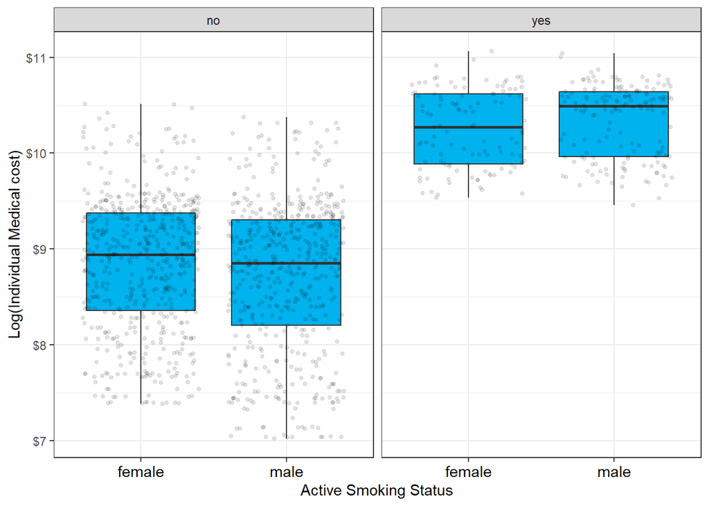

피보험자의 의료 비용과 관련하여 이러한 변수에는 상호 작용이 관찰되지 않습니다

#### Region of residence

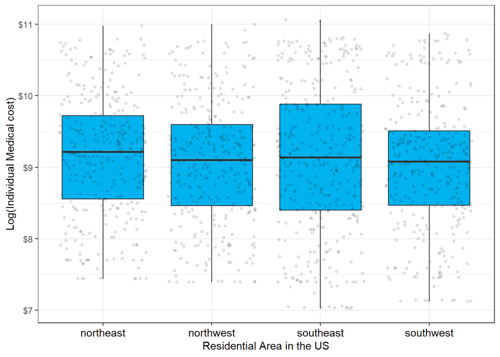

피보험자의 거주 지역에 대한 반응 변수에는 관련 변화가 관찰되지 않았습니다.

#### Number of children

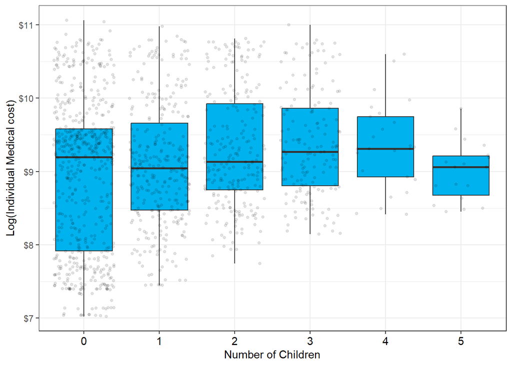

대부분의 피보험자들은 보험에 가입한 자녀가 0명에서 1명 사이인 것으로 보이지만 이는 각 피보험자가 부담하는 의료비와 관련이 없는 것으로 보입니다.

#### Numeric variables

다음으로 numerical variables(수치변수) 와 response variable(반응변수)의 관계를 탐색

##### Age of the insured

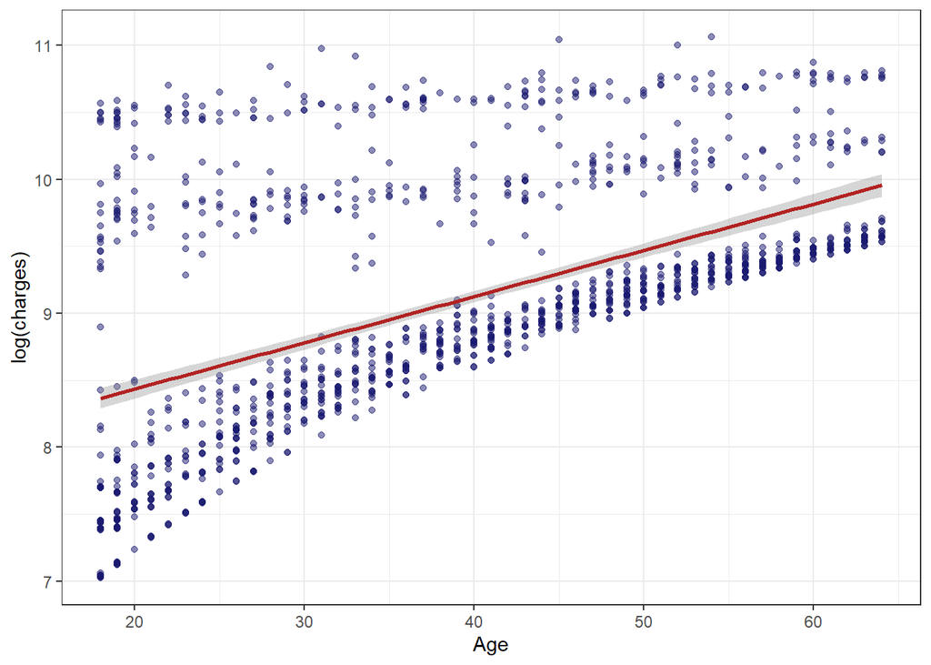

가입자 연령과 의료비 사이에는 양의 선형 관계가 관찰되었으나, 이전 그래프를 보면 흡연 여부가 반응 변수에 큰 영향을 미치는 것으로 나타났습니다.

이것과 피보험자의 연령 사이에 어떤 관계가 있습니까?

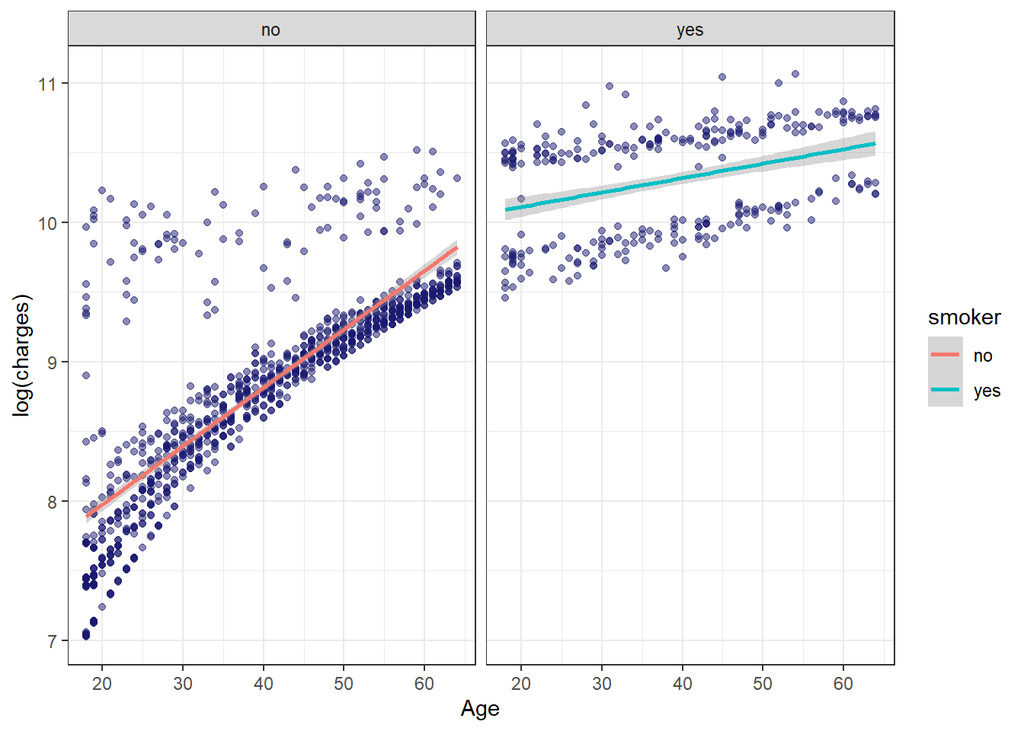

`평균 의료 비용`의 차이를 보여주는 이러한 변수 사이에는 `interactions(상호작용)`이 있습니다. 모델에서 이 `interactions` 을 사용하는 것이 좋습니다.

##### Body mass index(BMI)

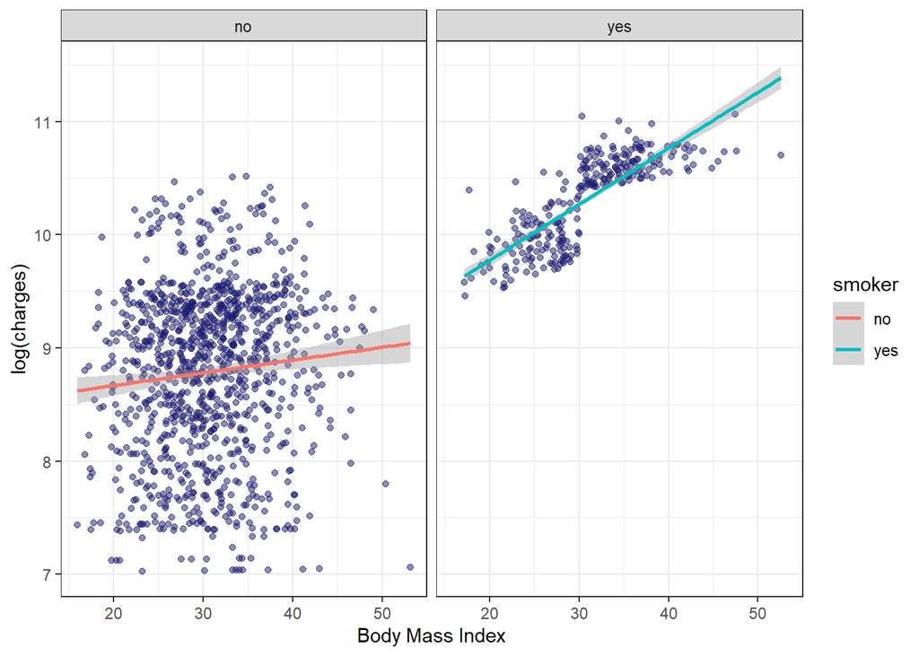

이전 단계와 마찬가지로 여기에서도 의료 비용과 관련하여 이러한 변수들 사이에 또 다른 명백한 상호 작용이 있는 것으로 보입니다.

### 2. Split data

#### Training and testing sets

사용 가능한 모든 데이터를 사용하여 지도 학습 모델을 수행하는 것은 일반적으로 `overfitting(과적합)` 문제를 일으키기 때문에 좋은 선택이 아닙니다. 데이터를 두 개의 세트로 분할하는 것이 좋습니다. 하나는 모델을 훈련하고 다른 하나는 모델을 테스트하는 데 사용됩니다. 이를 통해 새로운 데이터에 대한 모델의 성능을 알 수 있습니다.

```r
# Split 80% / 20%
set.seed(123)
split <- initial_split(data = insurance, prop = 0.80, strata = charges)

# Training set
train_set <- training(split)

# Testing set
test_set <- testing(split)
```

#### Cross validation

데이터를 훈련 세트와 테스트 세트로 분할하는 것 외에도 훈련 세트는 5개의 데이터 하위 집합으로 분할되므로 하이퍼파라미터 조정 프로세스의 결과를 훈련하고 측정하기 위한 다양한 partitions(파티션)을 가질 수 있습니다.

```r
set.seed(123)
folds <- vfold_cv(train_set, strata = charges, v = 5)
```

#### Feature engineering

탐색적 분석에서 관찰된 내용을 바탕으로 `feature engineering`을 사용한 전처리를 통해 `recipe`가 생성됩니다

### 3. Preprocessing `recipe`

데이터 전처리 `recipe`에 포함될 단계는 아래에 설명되어 있습니다.

- response variable(반응변수)에 대해 로그변환을 수행한다.
- 피보험자가 체질량지수에 따라 비만으로 분류될 수 있는지 여부를 나타내는 새로운 categorical variable(범주형 변수)가 생성됩니다.
- 모든 예측 변수가 정규화되었습니다.
- 모든 범주형 변수는 Dummy로 변환됩니다.
- 마지막으로 데이터의 탐색적 분석에서 관찰된 interactions(상호작용)이 생성됩니다.

```r
recipe <-
  recipe(charges ~ ., data = train_set) %>%
  step_log(all_outcomes()) %>%
  step_mutate(is_obsessive =
                if_else(bmi > 30, "Yes", "No") %>%
                factor(levels = c("Yes", "No"))) %>%
  step_normalize(all_numeric_predictors()) %>%
  step_dummy(all_nominal_predictors()) %>%
  step_interact(terms = ~ smoker_yes:age) %>%
  step_interact(terms = ~ smoker_yes:bmi)
```

#### Hyperparameter tuning

우리는 이미 데이터 전처리가 포함된 `recipe`를 가지고 있으므로 `Random Forest` 모델의 workflow 와 조정할 수 있는 하이퍼파라미터의 가능한 모든 조합을 갖춘 그리드만 설정하면 됩니다.

조정할 세 가지 주요 하이퍼 매개변수는 다음과 같습니다.

- mtry: 트리 모델을 생성할 때 각 분할에서 무작위로 샘플링될 예측변수 수에 대한 정수입니다.
- tree: 앙상블에 포함된 나무 수에 대한 정수입니다.
- min_n: 노드를 추가로 분할하는 데 필요한 노드의 최소 데이터 포인트 수에 대한 정수입니다.

### 4. Model spec(모델 사양)

```r
# Random forest spec (랜덤 포레스트의 사양 정의)
rf_spec <- rand_forest(
  mtry = tune(),      # 튜닝 파라미터: mtry (분할할 변수의 개수)
  trees = tune(),     # 튜닝 파라미터: trees (나무의 개수)
  min_n = tune()       # 튜닝 파라미터: min_n (리프 노드의 최소 관측치 개수)
) %>%
  set_engine(
    "ranger",          # 사용할 엔진 (ranger 패키지 사용)
    num.threads = 7,   # 병렬 처리할 스레드의 개수
    importance = "impurity"  # 변수 중요도 계산 방법
  ) %>%
  set_mode("regression")  # 모델의 종류: 회귀 모델

# Ranfom forest workflow
rf_Wf <- workflow() %>%
  add_recipe(recipe) %>%   # 데이터 전처리 및 특성 공학을 담당하는 recipe 객체 추가
  add_model(rf_spec)       # 랜덤 포레스트 모델 사양을 워크플로우에 추가
```

#### Setting grid

하이퍼파라미터에 대해 가능한 값의 그리드를 설정하기 위해 공간을 채우는 방법이 사용됩니다. 자세한 내용은 (https://www.tmwr.org/grid-search.html)

```r
# Space-filling designs grid
rf_grid <-
  grid_latin_hypercube(
    min_n(),
    mtry(range = c(4, 9)),
    trees(),
    size = 80)
```

이제 grid를 visualize(시각화) 해 보겠습니다.

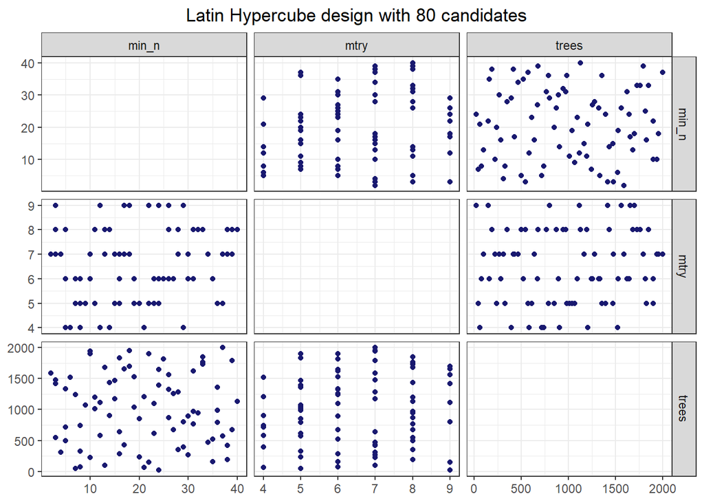

#### Tuning Hyperparameters

```r
# Lets use 7 cores for this process
doParallel::registerDoParallel(cores = 7)

set.seed(123)
tune_res <-
  rf_Wf %>%
  tune_grid(
    resamples = folds, grid = rf_grid,
    metrics = metric_set(rmse, mae, rsq)
    )
```

이제 tuning results를 visualize 해 보겠습니다.

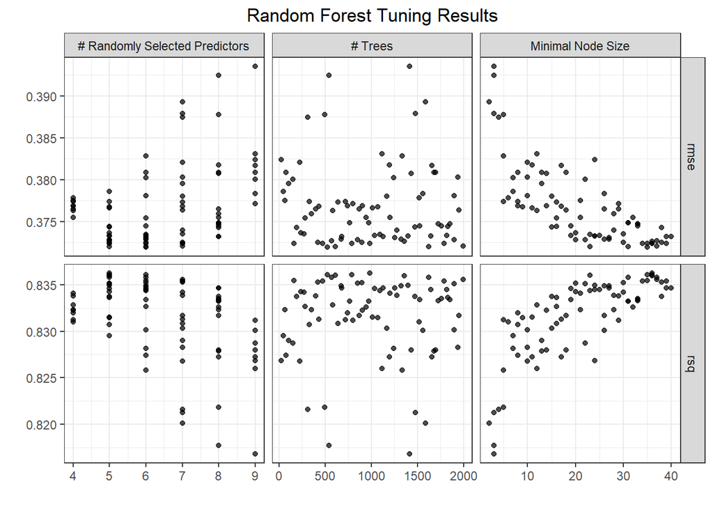

`root mean square error`를 최소화하기 위한 최적의 5개 모델입니다.

| .config | .metric | mtry | trees | min_n | mean |
| --- | --- | --- | --- | --- | --- |
| Preprocessor1_Model14 | rmse | 6 | 525 | 35 | 0.3719130 |
| Preprocessor1_Model21 | rmse | 6 | 1621 | 31 | 0.3719945 |
| Preprocessor1_Model47 | rmse | 5 | 613 | 23 | 0.3720179 |
| Preprocessor1_Model04 | rmse | 7 | 1998 | 37 | 0.3720898 |
| Preprocessor1_Model42 | rmse | 5 | 790 | 36 | 0.3723533 |

coefficient of determination(결정계수)를 최대화하기 위한 최고의 5개 모델입니다.

| .config | .metric | mtry | trees | min_n | mean |
| --- | --- | --- | --- | --- | --- |
| Preprocessor1_Model57 | rsq | 5 | 983 | 36 | 0.8362315 |
| Preprocessor1_Model14 | rsq | 6 | 525 | 35 | 0.8360723 |
| Preprocessor1_Model42 | rsq | 5 | 790 | 36 | 0.8360524 |
| Preprocessor1_Model47 | rsq | 5 | 613 | 23 | 0.8359879 |
| Preprocessor1_Model09 | rsq | 5 | 1356 | 36 | 0.8359692 |

### 6. Final Model

```r
# finalize model set up
final_rf <- rf_Wf %>%
  finalize_workflow(
    show_best(x = tune_res, metric = "rmse", n = 1)
  )
```

이제 성능을 확인하기 위해 최종 모델을 테스트 세트에 맞춰 보겠습니다.

```r
final_rs <-
  final_rf %>%
  last_fit(
    split, metrics = metric_set(rmse, mae, rsq)
    )
```

관찰된 값과 예측된 값 사이의 일치를 시각적으로 평가하는 가장 쉬운 방법은 scatterplot(산점도)를 사용하는 것입니다.

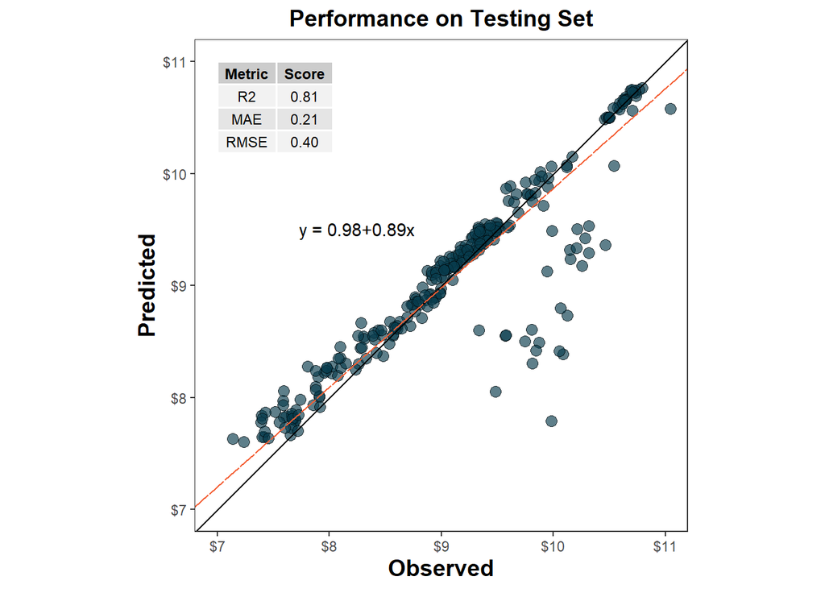

좋아 보이지만 어떤 사람들에게는 모델이 값을 과소평가하는 경향이 있는 것 같습니다.

### 7. Variable importance determination

변수 중요도 결정

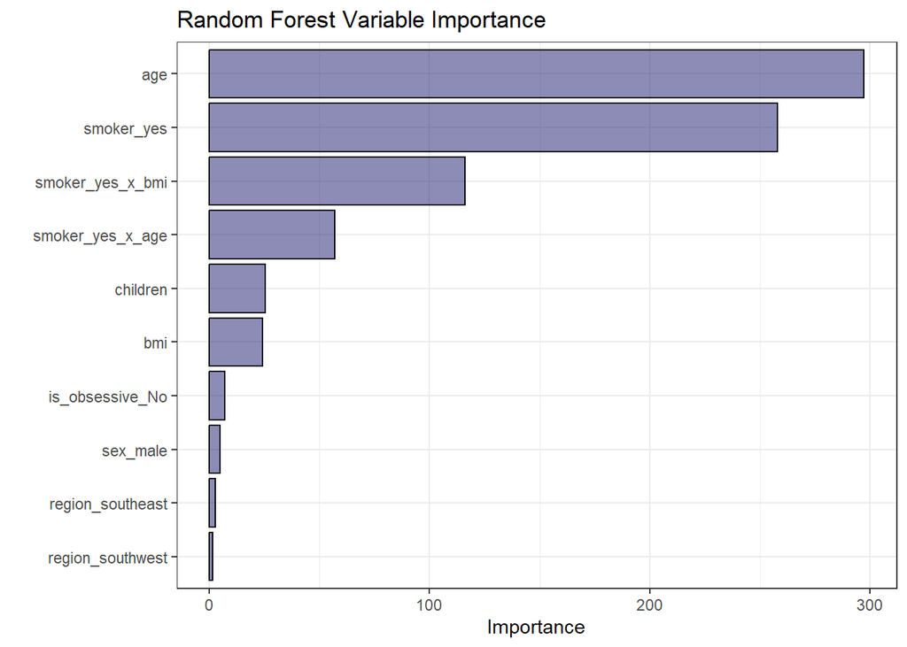

위의 그래프를 통해 피보험자의 연령과 흡연상태가 의료비를 예측하는 주요 변수임을 알 수 있다. 또한 변수 간의 상호작용은 관련성이 있는 것으로 보이며, 데이터의 탐색적 분석에서 관찰된 바와 같이 성별과 피보험자가 위치한 지역은 관련성이 없는 것으로 보입니다.